# Exam 1 Redo

Rahmat Ashari

Mar 07, 2020

**Original score = 52/60**

**Questions with more than 1 point lost = Q2, Q5, Q6**

# Question 2

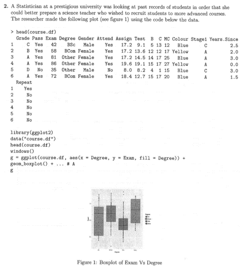

### a)

Exam is a quantitative variable! T/F?

Answer **T**

### b)

Gender is a qualitative variable! T/F?

Answer **T**

### c)

What Degree shows the smallest median Exam grade? see fig 1 on the preceding page

Degree with the smallest Exam median: **BSc**

### d)

What Degree has the smallest Exam IQR? see figure 1 on the precedng page

Degree with smallest Exam IQR: **BSc**

### e)

What function should be where the elipsis is placed in Line A? (Hint: geom_)?

Answer: **geom_point()**

# Question 5

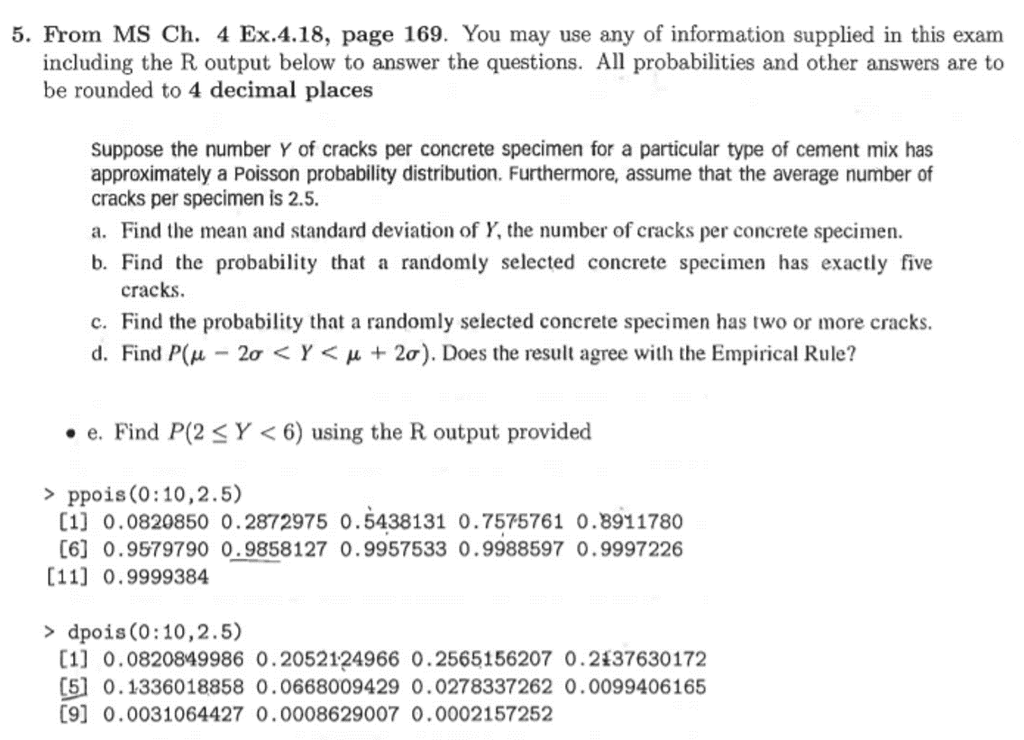

### a)

Find the mean and the std dev of Y, the number of cracks per specimen

$$\mu_y = \lambda = 2.5$$

$$\sigma_y = \sqrt{\lambda} = \sqrt{2.5} = 1.5811$$

### b)

Find the probability that a randomly selected concrete speciment has exactly 5 cracks.

```r
round(dpois(5,2.5),4)
```

```
## [1] 0.0668
```

### c)

Find the probability that a randomly selected conrete specimen has two or more cracks.

$$P(Y \geq 2) = 1 - P(Y \leq 1)$$

```r
round(1 - ppois(1, 2.5), 4)
```

```
## [1] 0.7127
```

### d)

Find the probability of $P(\mu - 2\sigma < Y < \mu + 2\sigma)$. Does the result agree with the Empirical Rule?

$$P(\mu - 2\sigma < Y < \mu + 2\sigma)$$
$$P(2.5 - 2(1.5811) < Y < 2.5 + 2(1.5811))$$
$$P(-0.6622 < Y < 5.6622)$$

For Poisson distribution, such probability can be computed as:

$$P( Y \leq 5)$$

```r
round(ppois(5,2.5),4)
```

```
## [1] 0.958
```

Empirical rule states that 95% of data lies within two standard deviation of the mean.

**Hence, result agrees with the Empirical Rule is True.**

### e)

Find $P(2 \leq Y < 6)$ using the R output provided

The question can be computed as:

$$P(2 \leq Y < 6) = P(Y \leq 5) - P(Y \leq 1)$$

```r
answer5 = ppois(5, 2.5) - ppois(1, 2.5)
round(answer5,4)
```

```
## [1] 0.6707
```

# Question 6

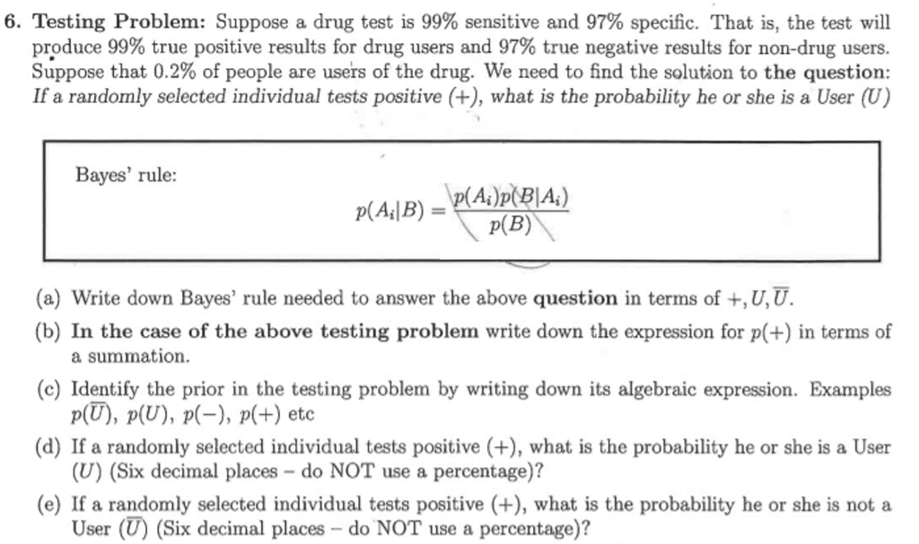

### a)

Write down Bayes’ rule needed to answer the above question in terms of $+, U, \overline{U}$

$$P(U|+) = \frac{P(U)P(+|U)}{P(U)P(+|U)+P(\overline{U}P(+|\overline{U})}$$

### c)

Identify the prior in the tetsing problem

**The prior is $P(U)$**

### d)

If a randomly selected individual tests positive (+), what is the probability he or she is a User (U)?

$P(U) = 0.002$

$P(\overline{U}) = 1 - 0.002 = 0.998$

$P(-|\overline{U}) = 0.97$

$P(+|\overline{U}) = 1 - P(-|\overline{U}) = 1 - 0.97 = 0.03$

$$P(U|+) = \frac{P(U)P(+|U)}{P(U)P(+|U)+P(\overline{U}P(+|\overline{U})}$$

$$P(U|+) = \frac{0.002*0.99}{0.02*0.99 + 0.998*0.03}$$

$$P(U|+) = 0.062030$$

### e)

If a randomly selected individual tests positive (+), what is the probability he or she is *not* a User ($\overline{U}$)?

$$P(\overline{U}|+) = 1 - P(U|+)$$
$$P(\overline{U}|+) = 1 - 0.062030 = 0.937970$$